# DATS 6101 - Midterm

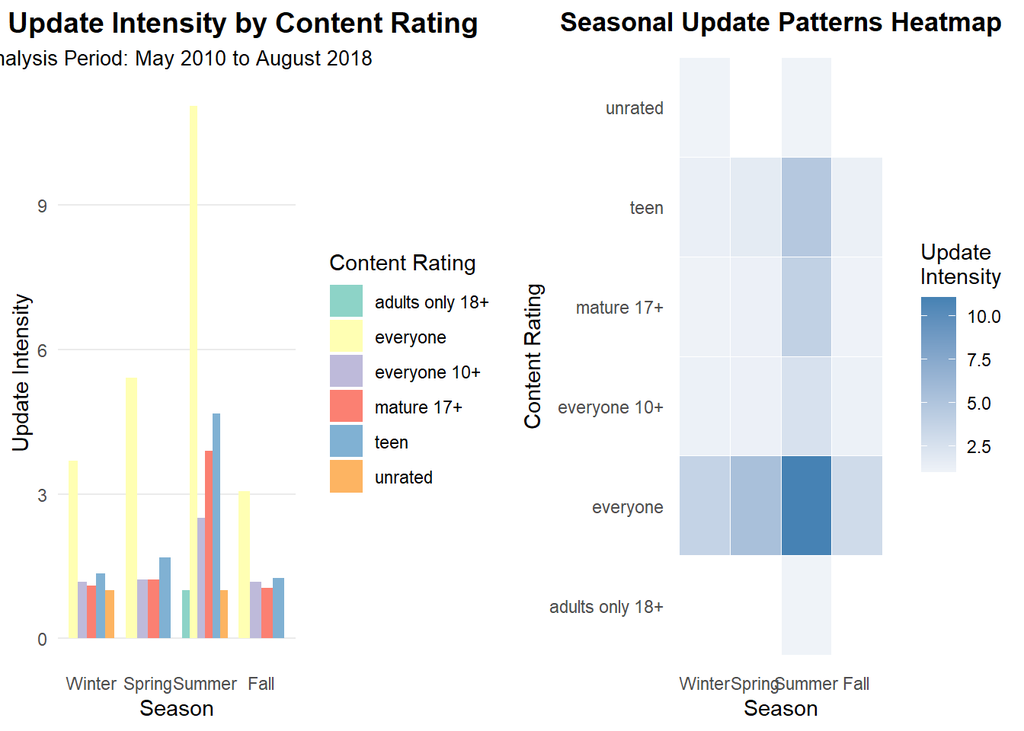

```r
# Create data_updated with seasonal information while keeping data_final unchanged
data_updated <- data_final %>%
  mutate(
    last_updated = as.Date(Last.Updated),
    current_date = Sys.Date(),
    days_since_update = as.numeric(difftime(current_date, last_updated, units = "days")),
    update_month = month(last_updated),
    season = case_when(
      update_month %in% c(12, 1, 2) ~ "Winter",
      update_month %in% c(3, 4, 5) ~ "Spring",
      update_month %in% c(6, 7, 8) ~ "Summer",
      update_month %in% c(9, 10, 11) ~ "Fall"
    )
  ) %>%
  filter(!is.na(last_updated), !is.na(days_since_update))

# Calculate seasonal update intensity
seasonal_intensity <- data_updated %>%
  group_by(Content.Rating, season) %>%
  summarise(
    update_count = n(),
    update_intensity = n() / n_distinct(last_updated),
    avg_days_between_updates = mean(days_since_update, na.rm = TRUE),
    .groups = 'drop'
  ) %>%
  mutate(season = factor(season, levels = c("Winter", "Spring", "Summer", "Fall"))) %>%
  arrange(Content.Rating, desc(update_intensity))

# Create enhanced seasonal bar plot
seasonal_plot <- ggplot(seasonal_intensity,
       aes(x = season, y = update_intensity, fill = Content.Rating)) +
  geom_bar(stat = "identity", position = "dodge", width = 0.8) +
  scale_fill_brewer(palette = "Set3") +
  labs(
    title = "Seasonal Update Intensity by Content Rating",
    subtitle = paste("Analysis Period:", format(min(data_updated$last_updated), "%B %Y"),
                    "to", format(max(data_updated$last_updated), "%B %Y")),
    x = "Season",
    y = "Update Intensity",
    fill = "Content Rating"
  ) +
  theme_minimal() +
  theme(
    plot.title = element_text(hjust = 0.5, face = "bold", size = 14),
    plot.subtitle = element_text(hjust = 0.5, size = 10),
    axis.text.x = element_text(angle = 0),
    panel.grid.major.x = element_blank(),
    panel.grid.minor = element_blank(),
    legend.position = "right"
  )

# Create seasonal heatmap
seasonal_heatmap <- ggplot(seasonal_intensity,
       aes(x = season, y = Content.Rating, fill = update_intensity)) +
  geom_tile(color = "white") +
  scale_fill_gradient2(
    low = "white",
    high = "steelblue",
    name = "Update\nIntensity"
  ) +
  labs(
    title = "Seasonal Update Patterns Heatmap",
    x = "Season",
    y = "Content Rating"
  ) +
  theme_minimal() +
  theme(
    plot.title = element_text(hjust = 0.5, face = "bold"),
    axis.text.x = element_text(angle = 0),
    panel.grid = element_blank(),
    legend.position = "right"
  )

# Print both plots side by side
library(gridExtra)
grid.arrange(seasonal_plot, seasonal_heatmap, ncol = 2)
```

```r
# Print seasonal statistics
print("\nSeasonal Update Intensity Statistics:")
```

```
## [1] "\nSeasonal Update Intensity Statistics:"
```

```r
print(seasonal_intensity)
```

```
## # A tibble: 19 × 5
##    Content.Rating  season update_count update_intensity avg_days_between_updates
##    <chr>           <fct>         <int>            <dbl>                    <dbl>
##  1 adults only 18+ Summer            3             1                       2291.
##  2 everyone        Summer         3992            11.1                     2430.
##  3 everyone        Spring         1826             5.42                    2590.
##  4 everyone        Winter         1202             3.70                    2751.
##  5 everyone        Fall            883             3.06                    2870.
##  6 everyone 10+    Summer          190             2.5                     2393.
##  7 everyone 10+    Spring           54             1.23                    2624.
##  8 everyone 10+    Fall             32             1.19                    2874
##  9 everyone 10+    Winter           46             1.18                    2742.
## 10 mature 17+      Summer          269             3.90                    2332.
## 11 mature 17+      Spring           59             1.23                    2621.
## 12 mature 17+      Winter           44             1.1                     2674.
## 13 mature 17+      Fall             21             1.05                    2895.
## 14 teen            Summer          612             4.67                    2399.
## 15 teen            Spring          203             1.69                    2579.
## 16 teen            Winter          109             1.35                    2740.
## 17 teen            Fall            112             1.26                    2863.
## 18 unrated         Summer            1             1                       3414
## 19 unrated         Winter            1             1                       4627
```

```r
# Additional seasonal summary
seasonal_summary <- data_updated %>%
  group_by(season) %>%
  summarise(
    total_updates = n(),
    avg_days_since_update = mean(days_since_update, na.rm = TRUE),
    median_days_since_update = median(days_since_update, na.rm = TRUE),
    n_apps = n_distinct(Content.Rating),
    .groups = 'drop'
  ) %>%
  arrange(match(season, c("Winter", "Spring", "Summer", "Fall")))

print("\nOverall Seasonal Summary:")
```

```
## [1] "\nOverall Seasonal Summary:"
```

```r
print(seasonal_summary)
```

```
## # A tibble: 4 × 5
##   season total_updates avg_days_since_update median_days_since_update n_apps
##   <chr>          <int>                 <dbl>                    <dbl>  <int>
## 1 Winter          1402                 2748.                    2506       5
## 2 Spring          2142                 2591.                    2401       4
## 3 Summer          5067                 2420.                    2297       6
## 4 Fall            1048                 2870.                    2602.      4
```

#### Visualization for Content Rating vs Installs

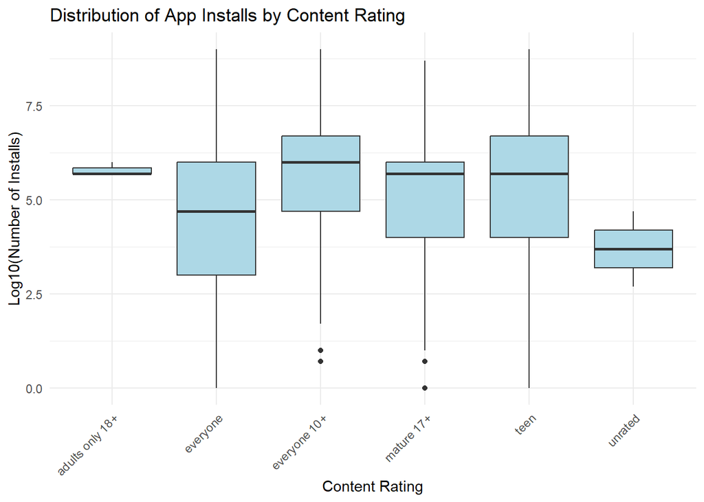

```r
installs_by_rating <- data_updated %>%
  group_by(Content.Rating) %>%
  summarise(
    mean_installs = mean(Installs, na.rm = TRUE),
    median_installs = median(Installs, na.rm = TRUE),
    total_installs = sum(Installs, na.rm = TRUE),
    n_apps = n()
  ) %>%
  arrange(desc(mean_installs))

# Visualize distribution of installs by content rating
ggplot(data_updated, aes(x = Content.Rating, y = log10(Installs))) +
  geom_boxplot(fill = "lightblue") +
  labs(title = "Distribution of App Installs by Content Rating",
       x = "Content Rating",
       y = "Log10(Number of Installs)") +
  theme_minimal() +
  theme(axis.text.x = element_text(angle = 45, hjust = 1))
```

#### Distribution of Installations by Update Recency and Content Rating

```r
data_analysis <- data_updated %>%
  mutate(
    days_since_update = as.numeric(difftime(max(Last.Updated), Last.Updated, units = "days")),
    update_year = year(Last.Updated),
    update_month = month(Last.Updated)
  )


data_analysis <- data_analysis %>%
  mutate(update_recency = ifelse(days_since_update <= median(days_since_update),
                                "Recent Update", "Old Update"))

recent_vs_old <- data_analysis %>%
  group_by(Content.Rating, update_recency) %>%
  summarise(
    mean_installs = mean(Installs, na.rm = TRUE),
    median_installs = median(Installs, na.rm = TRUE),
    n_apps = n()
  )

print("\nComparison of Installs by Update Recency and Content Rating:")
```

```
## [1] "\nComparison of Installs by Update Recency and Content Rating:"
```

```r
print(recent_vs_old)
```

```
## # A tibble: 10 × 5
## # Groups:   Content.Rating [6]
##    Content.Rating  update_recency mean_installs median_installs n_apps
##    <chr>           <chr>                  <dbl>           <dbl>  <int>
##  1 adults only 18+ Recent Update        666667.          500000      3
##  2 everyone        Old Update          1787608.           10000   4110
##  3 everyone        Recent Update      11819742.          500000   3793
##  4 everyone 10+    Old Update          2711120.          100000    135
##  5 everyone 10+    Recent Update      19520163.         1000000    187
##  6 mature 17+      Old Update           875646.          100000    118
##  7 mature 17+      Recent Update       8489675.          500000    275
##  8 teen            Old Update          1625562.           50000    441
##  9 teen            Recent Update      26504878.         1000000    595
## 10 unrated         Old Update            25250            25250      2
```

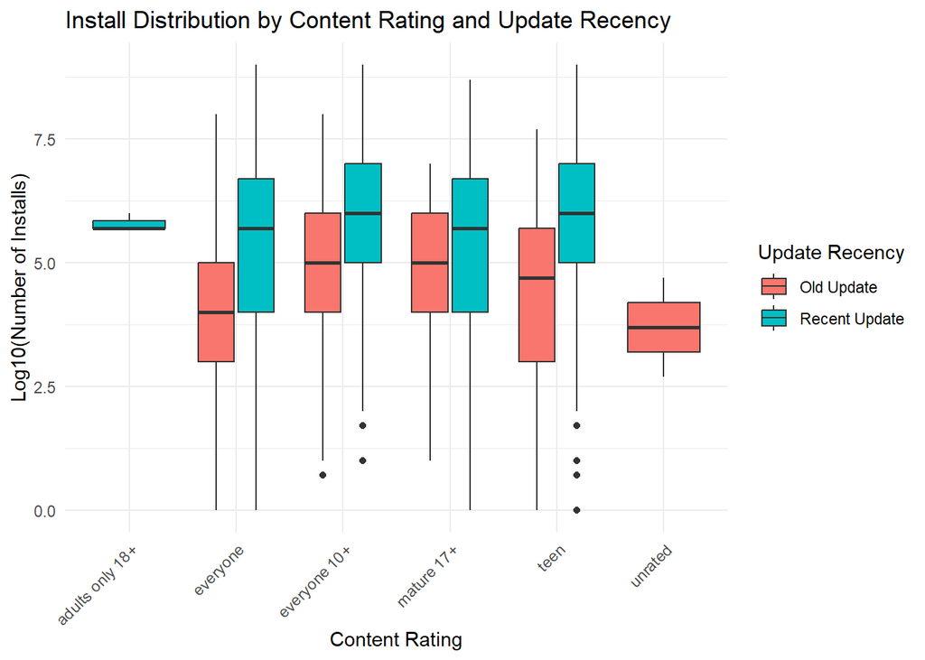

```r
# 7. Visualization of update recency effect
ggplot(data_analysis, aes(x = Content.Rating, y = log10(Installs), fill = update_recency)) +
  geom_boxplot() +
  labs(title = "Install Distribution by Content Rating and Update Recency",
       x = "Content Rating",
       y = "Log10(Number of Installs)",
       fill = "Update Recency") +
  theme_minimal() +
  theme(axis.text.x = element_text(angle = 45, hjust = 1))
```

#### Visualization for Last Updated vs Content Rating vs Installs

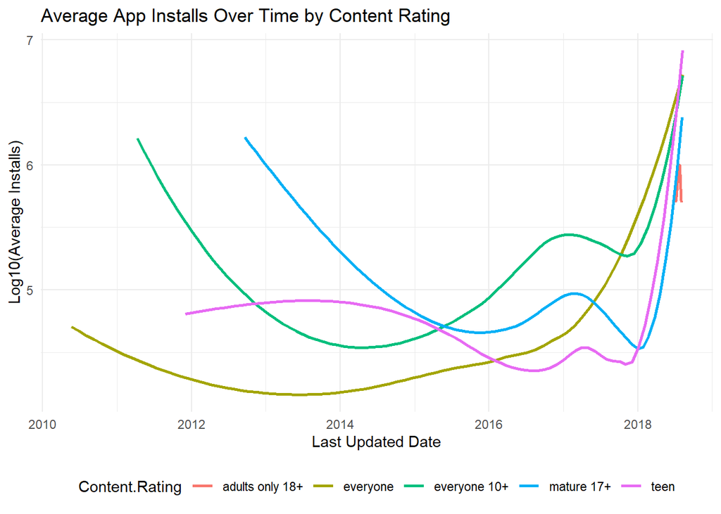

```r
# 3. Timeline analysis: Average installs over time by content rating
installs_timeline <- data_updated %>%
  group_by(Content.Rating, Last.Updated) %>%
  summarise(avg_installs = mean(Installs, na.rm = TRUE)) %>%
  ungroup()

ggplot(installs_timeline, aes(x = Last.Updated, y = log10(avg_installs), color = Content.Rating)) +
  geom_smooth(method = "loess", se = FALSE) +
  labs(title = "Average App Installs Over Time by Content Rating",
       x = "Last Updated Date",
       y = "Log10(Average Installs)") +
  theme_minimal() +
  theme(legend.position = "bottom")
```

The line graph depicts the trend of average app installs over time for different content ratings, with the y-axis on a logarithmic scale (`log10`). The curves reveal that apps with broader content ratings like “everyone” and “everyone 10+” show significant growth in average installs, particularly from 2016 onwards, reaching a peak around 2018. This indicates a surge in popularity and possibly greater user engagement or app availability during that period. Similarly, “mature 17+” apps follow a parallel trend but start with higher average installs and decline around 2012 before recovering alongside the other categories.